# Código Comentado

Fernando Bispo

05 julho, 2021

# 1 Motivação

O objetivo deste documento é gerar um **passo a passo comentado** da elaboração do código para a criação do relatório, a fim de possibilitar em uma consulta futura a análise do código feito e a metodologia que permitiu o sucesso da aplicação de algumas técnicas de programação, bem como avaliar os resultados e obter o entendimento da construção desse código.

# 2 Carregamento de pacotes

```r
library(dplyr)
library(ggplot2) #Criação de gráficos.
library(ggrepel) #Estilos de texto nos gráficos.
library(knitr) #Estruturação de tabelas.
library(kableExtra) #Estilização de tabelas.
```

# 3 Importação do BD

Iniciei importando o BD para análise inicial e manipulação dos dados.

```r
#Código omitido.
```

Visualizando os Bancos de dados

```r
#Banco de dados de 2018.1
glimpse(disciplinas_2018_1)
```

```
## Rows: 96
## Columns: 18
## $ ID             <dbl> 1, 2, 3, 4, 5, 6, 7, 8, 9, 10, 11, 12, 13, 14, 15, 16, ~
## $ q1             <dbl> 5, 5, 5, 5, 5, 2, 5, 5, 2, 5, 3, 5, 5, 4, 5, 5, 5, 5, 5~
## $ q2             <dbl> 5, 5, 5, 5, 5, 3, 5, 5, 5, 5, 5, 2, 5, 5, 5, 5, 5, 5, 5~
## $ q3             <dbl> 5, 5, 5, 5, 2, 4, 5, 5, 3, 5, 1, 5, 5, 5, 5, 5, 5, 5, 5~
## $ q4             <dbl> 5, 5, 5, 5, 2, 4, 5, 5, 3, 5, 1, 4, 5, 2, 5, 3, 5, 5, 5~
## $ q5             <dbl> 5, 5, 5, 5, 3, 1, 5, 5, 5, 5, 2, 5, 5, 4, 5, 5, 5, 5, 5~
## $ q6             <dbl> 5, 5, 5, 5, 3, 4, 5, 5, 3, 5, 2, 4, 5, 3, 5, 4, 5, 5, 5~
## $ q7             <dbl> 5, 5, 5, 5, 5, 4, 5, 5, 5, 5, 5, 4, 5, 5, 5, 5, 5, 5, 5~
## $ q8             <dbl> 5, 5, 5, 5, 4, 4, 5, 5, 3, 5, 2, 5, 5, 3, 5, 2, 5, 5, 5~
## $ q9             <dbl> 5, 5, 5, 5, 5, 2, 5, 5, 5, 5, 2, 5, 5, 5, 5, 5, 5, 5, 5~
## $ q10            <dbl> 5, 5, 2, 5, 5, 3, 5, 5, 5, 5, 5, 5, 5, 5, 5, 5, 5, 5, 5~
## $ q11            <dbl> 4, 5, 5, 5, 5, 2, 4, 5, 5, 5, 4, 5, 4, 5, 2, 5, 3, 1, 1~
## $ q12            <dbl> 5, 2, 5, 5, 5, 4, 4, 5, 4, 5, 4, 4, 4, 5, 5, 5, 4, 5, 5~
## $ comentariodisc <chr> NA, NA, NA, NA, NA, NA, "Melhor professora !", NA, NA, ~
## $ MATRICULA      <dbl> 201517019, 217220657, 201517019, 201517019, 217220657, ~
## $ DISCIPLINA     <chr> "ISCA82", "MAT229", "MAT045", "MAT224", "MATD43", "MATD~
## $ TURMA          <dbl> 90900, 10100, 20200, 10100, 10000, 10000, 10100, 10000,~
## $ SITUACAO       <chr> "aprovado", "aprovado", "aprovado", "aprovado", "aprova~
```

```r
#Banco de dados de 2018.2
glimpse(disciplinas_2018_2)
```

```
## Rows: 58
## Columns: 18
## $ ID         <dbl> 32, 33, 34, 35, 36, 37, 38, 39, 40, 41, 42, 43, 44, 45, 46,~
## $ q1         <dbl> 0, 5, 4, 5, 5, 5, 5, 5, 5, 5, 4, 5, 0, 3, 0, 5, 5, 5, 3, 5,~
## $ q2         <dbl> 0, 5, 4, 5, 5, 5, 5, 4, 5, 5, 5, 2, 0, 5, 0, 5, 5, 5, 3, 5,~
## $ q3         <dbl> 0, 5, 4, 5, 5, 5, 4, 4, 5, 5, 5, 4, 0, 5, 0, 5, 5, 5, 1, 5,~
## $ q4         <dbl> 0, 4, 3, 5, 5, 5, 4, 4, 5, 5, 4, 3, 0, 4, 0, 5, 5, 5, 3, 4,~
## $ q5         <dbl> 0, 4, 4, 5, 4, 5, 5, 4, 5, 5, 4, 3, 0, 5, 0, 5, 5, 5, 4, 2,~
## $ q6         <dbl> 0, 4, 3, 5, 4, 5, 4, 3, 5, 5, 5, 4, 0, 4, 0, 5, 5, 5, 2, 4,~
## $ q7         <dbl> 0, 4, 4, 4, 5, 5, 5, 5, 5, 5, 5, 2, 0, 5, 0, 5, 5, 5, 3, 3,~
## $ q8         <dbl> 0, 5, 4, 5, 5, 5, 5, 5, 5, 5, 5, 5, 0, 3, 0, 5, 5, 5, 4, 5,~
## $ q9         <dbl> 0, 5, 4, 5, 5, 5, 5, 5, 5, 5, 5, 5, 0, 5, 0, 5, 5, 5, 4, 5,~
## $ q10        <dbl> 0, 3, 4, 5, 5, 5, 5, 5, 5, 5, 5, 5, 0, 5, 0, 5, 5, 3, 3, 5,~
## $ q11        <dbl> 0, 5, 5, 5, 5, 4, 4, 3, 5, 3, 4, 4, 0, 5, 0, 3, 3, 3, 5, 3,~
## $ q12        <dbl> 0, 1, 1, 1, 1, 3, 5, 3, 5, 5, 4, 5, 0, 5, 0, 5, 5, 2, 5, 5,~
## $ comentdisc <chr> NA, NA, NA, NA, NA, NA, NA, NA, NA, NA, NA, NA, "Professor ~
## $ MATRICULA  <dbl> 216115595, 216115595, 216115595, 216115595, 216115595, 2161~
## $ DISCIPLINA <chr> "MATD57", "MATD51", "MATD50", "MATD47", "MATD48", "MAT191",~
## $ TURMA      <dbl> 10000, 10000, 10100, 10100, 10100, 20200, 10000, 400, 10000~
## $ SITUACAO   <chr> "reprovadoFalta", "aprovado", "aprovado", "aprovado", "apro~
```

# 4 Limpeza e manipulação do BD

Antes de unir os BDs visualizarei os nomes das VAs afim de identificar possíveis divergências.

```r
colnames(disciplinas_2018_1)
```

```
##  [1] "ID"             "q1"             "q2"             "q3"
##  [5] "q4"             "q5"             "q6"             "q7"
##  [9] "q8"             "q9"             "q10"            "q11"
## [13] "q12"            "comentariodisc" "MATRICULA"      "DISCIPLINA"
## [17] "TURMA"          "SITUACAO"
```

```r
colnames(disciplinas_2018_2)
```

```
##  [1] "ID"         "q1"         "q2"         "q3"         "q4"
##  [6] "q5"         "q6"         "q7"         "q8"         "q9"
## [11] "q10"        "q11"        "q12"        "comentdisc" "MATRICULA"
## [16] "DISCIPLINA" "TURMA"      "SITUACAO"
```

Constatei que o nome da variavel Comentários da Disciplina estava diferente nos dois BDs, então renomeei em ambos os BDs e criei a VA **`SEMESTRE`**

```r
#Renomeação das VAs.
disciplinas_2018_1 <- disciplinas_2018_1 %>%
  rename(COMENTARIOS_DISC = comentariodisc)

disciplinas_2018_2 <- disciplinas_2018_2 %>%
  rename(COMENTARIOS_DISC = comentdisc)
#Criação da VA SEMESTRE.
disciplinas_2018_1 <- disciplinas_2018_1 %>%
  mutate(SEMESTRE = 2018.1)

disciplinas_2018_2 <- disciplinas_2018_2 %>%
  mutate(SEMESTRE = 2018.2)
```

Após esse procedimento uni os dois BDs

```r
#União dos BDs
disciplinas_2018 <- full_join(disciplinas_2018_1, disciplinas_2018_2)
```

```r
#Transformação do BD para fator.
disciplinas_2018 <- disciplinas_2018 %>%
  mutate_all(as.factor)

#Transformando algumas variaveis do BD em caractere e alterando o formato de strings.
disciplinas_2018 <- disciplinas_2018 %>%
  mutate(COMENTARIOS_DISC = as.character(COMENTARIOS_DISC),
         DISCIPLINA = as.character(DISCIPLINA),
         SITUACAO = stringr::str_to_title(SITUACAO))

glimpse(disciplinas_2018) #Visualização da estrutura.
```

```
## Rows: 154
## Columns: 19
## $ ID               <fct> 1, 2, 3, 4, 5, 6, 7, 8, 9, 10, 11, 12, 13, 14, 15, 16~
## $ q1               <fct> 5, 5, 5, 5, 5, 2, 5, 5, 2, 5, 3, 5, 5, 4, 5, 5, 5, 5,~
## $ q2               <fct> 5, 5, 5, 5, 5, 3, 5, 5, 5, 5, 5, 2, 5, 5, 5, 5, 5, 5,~
## $ q3               <fct> 5, 5, 5, 5, 2, 4, 5, 5, 3, 5, 1, 5, 5, 5, 5, 5, 5, 5,~
## $ q4               <fct> 5, 5, 5, 5, 2, 4, 5, 5, 3, 5, 1, 4, 5, 2, 5, 3, 5, 5,~
## $ q5               <fct> 5, 5, 5, 5, 3, 1, 5, 5, 5, 5, 2, 5, 5, 4, 5, 5, 5, 5,~
## $ q6               <fct> 5, 5, 5, 5, 3, 4, 5, 5, 3, 5, 2, 4, 5, 3, 5, 4, 5, 5,~
## $ q7               <fct> 5, 5, 5, 5, 5, 4, 5, 5, 5, 5, 5, 4, 5, 5, 5, 5, 5, 5,~
## $ q8               <fct> 5, 5, 5, 5, 4, 4, 5, 5, 3, 5, 2, 5, 5, 3, 5, 2, 5, 5,~
## $ q9               <fct> 5, 5, 5, 5, 5, 2, 5, 5, 5, 5, 2, 5, 5, 5, 5, 5, 5, 5,~
## $ q10              <fct> 5, 5, 2, 5, 5, 3, 5, 5, 5, 5, 5, 5, 5, 5, 5, 5, 5, 5,~
## $ q11              <fct> 4, 5, 5, 5, 5, 2, 4, 5, 5, 5, 4, 5, 4, 5, 2, 5, 3, 1,~
## $ q12              <fct> 5, 2, 5, 5, 5, 4, 4, 5, 4, 5, 4, 4, 4, 5, 5, 5, 4, 5,~
## $ COMENTARIOS_DISC <chr> NA, NA, NA, NA, NA, NA, "Melhor professora !", NA, NA~
## $ MATRICULA        <fct> 201517019, 217220657, 201517019, 201517019, 217220657~
## $ DISCIPLINA       <chr> "ISCA82", "MAT229", "MAT045", "MAT224", "MATD43", "MA~
## $ TURMA            <fct> 90900, 10100, 20200, 10100, 10000, 10000, 10100, 1000~
## $ SITUACAO         <chr> "Aprovado", "Aprovado", "Aprovado", "Aprovado", "Apro~
## $ SEMESTRE         <fct> 2018.1, 2018.1, 2018.1, 2018.1, 2018.1, 2018.1, 2018.~
```

Identifiquei Variaveis que não trariam informação, então exclui do BD.

```r
disciplinas_2018 <- disciplinas_2018 %>%
  select(-ID, -TURMA)
```

Para poder identificar e mensurar como os alunos avaliam as disciplinas do departamento, categorizei as disciplinas que pertenciam ao departamento e as que não pertencia através da criação da variável `DEPARTAMENTO`.

```r
disciplinas_2018 <- disciplinas_2018 %>%
  mutate(DEPARTAMENTO = ifelse(DISCIPLINA %in% c("ADM001", "ISCA82", "FCHC45",
                                                 "LETA09", "MAT045", "MAT174",
                                                 "MATE56"), "Não_DEst", "DEst"))
```

## 4.1 Visualizando o BD pronto

Após todas essa manipulações o BD ficou com a seguinte estrutura:

```r
kable(head(disciplinas_2018,10), col.names = c("Q1", "Q2", "Q3", "Q4", "Q5", "Q6", "Q7", "Q8", "Q9", "Q10", "Q11", "Q12", "Comentários", "Matrícula", "Disciplina", "Situação", "Semestre", "Departamento")) %>%
  kable_styling(bootstrap_options = c("striped", "hover", "condensed", "responsive"))
```

| Q1 | Q2 | Q3 | Q4 | Q5 | Q6 | Q7 | Q8 | Q9 | Q10 | Q11 | Q12 | Comentários | Matrícula | Disciplina | Situação | Semestre | Departamento |
| --- | --- | --- | --- | --- | --- | --- | --- | --- | --- | --- | --- | --- | --- | --- | --- | --- | --- |
| 5 | 5 | 5 | 5 | 5 | 5 | 5 | 5 | 5 | 5 | 4 | 5 | NA | 201517019 | ISCA82 | Aprovado | 2018.1 | Não_DEst |
| 5 | 5 | 5 | 5 | 5 | 5 | 5 | 5 | 5 | 5 | 5 | 2 | NA | 217220657 | MAT229 | Aprovado | 2018.1 | DEst |
| 5 | 5 | 5 | 5 | 5 | 5 | 5 | 5 | 5 | 2 | 5 | 5 | NA | 201517019 | MAT045 | Aprovado | 2018.1 | Não_DEst |
| 5 | 5 | 5 | 5 | 5 | 5 | 5 | 5 | 5 | 5 | 5 | 5 | NA | 201517019 | MAT224 | Aprovado | 2018.1 | DEst |
| 5 | 5 | 2 | 2 | 3 | 3 | 5 | 4 | 5 | 5 | 5 | 5 | NA | 217220657 | MATD43 | Aprovado | 2018.1 | DEst |
| 2 | 3 | 4 | 4 | 1 | 4 | 4 | 4 | 2 | 3 | 2 | 4 | NA | 201517019 | MATD41 | Aprovado | 2018.1 | DEst |
| 5 | 5 | 5 | 5 | 5 | 5 | 5 | 5 | 5 | 5 | 4 | 4 | Melhor professora ! | 201510582 | MAT224 | Aprovado | 2018.1 | DEst |
| 5 | 5 | 5 | 5 | 5 | 5 | 5 | 5 | 5 | 5 | 5 | 5 | NA | 217220657 | MATD44 | Aprovado | 2018.1 | DEst |
| 2 | 5 | 3 | 3 | 5 | 3 | 5 | 3 | 5 | 5 | 5 | 4 | NA | 218123951 | MAT198 | Reprovadonota | 2018.1 | DEst |
| 5 | 5 | 5 | 5 | 5 | 5 | 5 | 5 | 5 | 5 | 5 | 5 | NA | 217220657 | MATD45 | Aprovado | 2018.1 | DEst |

# 5 Criação de gráficos

Tentando replicar os gráficos feitos no relatório iniciei com o das disciplinas.

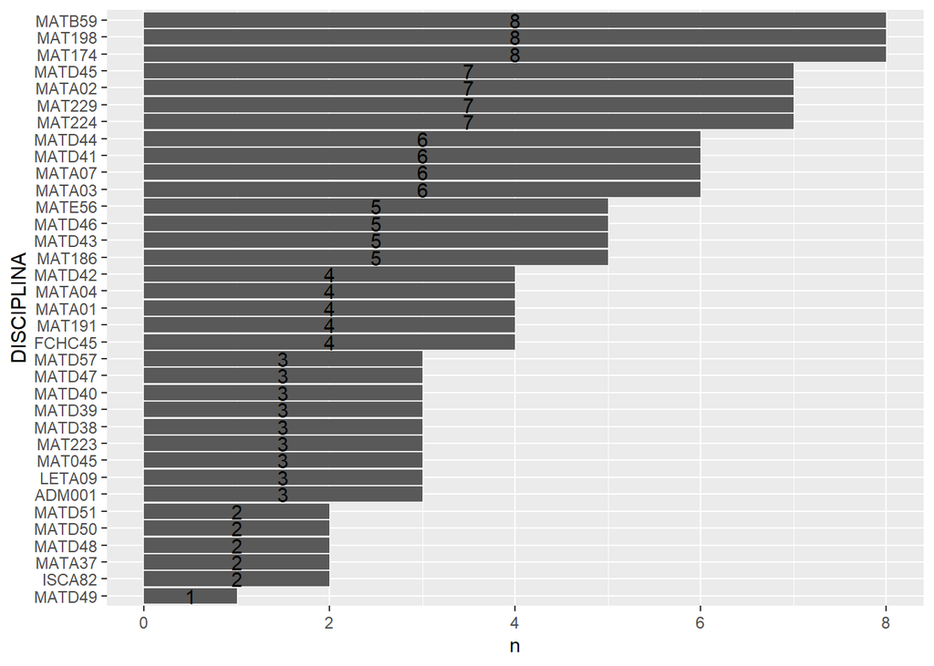

```r
disciplinas_2018 %>%
  count(DISCIPLINA) %>%
  # top_n(10, n) %>%  Estou na dúvida se devo listar todas as disciplinas ou apenas as que possuem mais matriculados.
  mutate(DISCIPLINA = forcats::fct_reorder(DISCIPLINA, n)) %>%
  ggplot(aes(x = DISCIPLINA)) +
  geom_col(aes(y = n), show.legend = FALSE) +
  geom_text(aes(y = n/2, label = n)) +
  coord_flip()
```

Após ler o relatório que a senhora desenvolveu, tentei replicar um dos gráficos e então surgiu a primeira dúvida: Como inserir os valores das respectivas porcentagens no gráfico de forma a deixalos centralizados nos seus respectivos locais?

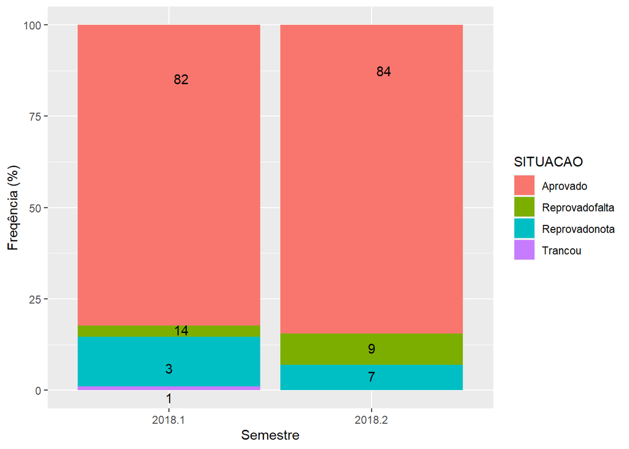

```r
disciplinas_2018 %>%
  group_by(SEMESTRE) %>%
  count(SITUACAO) %>%
  mutate(Fr = n/sum(n)*100) %>%
  ggplot(aes(x = SEMESTRE, y = Fr, fill = SITUACAO)) +
  geom_col() +
  geom_text_repel(aes(label = round(Fr,0))) +
  labs(x = "Semestre", y = "Freqência (%)")
```